# Review3 - Analysis of Youtube Trending Videos

### Reg. No: 18BCE1020

### Name: Chandan Kumar

# Problem Statement and Objectives

### What problem are you trying to solve?

I have curiosity in knowing the psychology behind a viewer who attracted them towards a particular video. This knowledge of psychology can be used to get a trending video in minimum time frame as well as we can get a highly watched and liked video.

### What data have you chosen?(Chosen Dataset, Source of dataset, Description of dataset, basic commands to describe dataset)

For this research I have used open dataset which is available on kaggle. The link for the dataset is https://www.kaggle.com/datasnaek/youtube-new I am using the latest version of this dataset.

YouTube (the world-famous video sharing website) maintains a list of the top trending videos on the platform. According to Variety magazine, “To determine the year’s top-trending videos, YouTube uses a combination of factors including measuring users interactions (number of views, shares, comments and likes).

This dataset is a daily record of the top trending YouTube videos.

Basically, this dataset contains 20 files in csv and json format. All these files correspond to a particular country. After summing of the number of rows, it has more than 2.6 lakhs entries. Moreover if we talk about the number of columns it has 16 cols. in total. It has id’s associated with each video and data associated with it. Data includes the video title, channel title, publish time, tags, views, likes and dislikes, description, and comment count.

Below is a sample of my dataset(used only one file)

```r
data=read.csv("CAvideos.csv")
dim(data)
```

```
## [1] 40881    16
```

```r
str(data)
```

```
## 'data.frame':    40881 obs. of  16 variables:
##  $ video_id              : chr  "n1WpP7iowLc" "0dBIkQ4Mz1M" "5qpjK5DgCt4" "d380meD0W0M" ...
##  $ trending_date         : chr  "17.14.11" "17.14.11" "17.14.11" "17.14.11" ...
##  $ title                 : chr  "Eminem - Walk On Water (Audio) ft. BeyoncÃ©" "PLUSH - Bad Unboxing Fan Mail" "Racist Superman | Rudy Mancuso, King Bach & Lele Pons" "I Dare You: GOING BALD!?" ...
##  $ channel_title         : chr  "EminemVEVO" "iDubbbzTV" "Rudy Mancuso" "nigahiga" ...
##  $ category_id           : int  10 23 23 24 10 25 23 22 24 22 ...
##  $ publish_time          : chr  "2017-11-10T17:00:03.000Z" "2017-11-13T17:00:00.000Z" "2017-11-12T19:05:24.000Z" "2017-11-12T18:01:41.000Z" ...
##  $ tags                  : chr  "Eminem|Walk|On|Water|Aftermath/Shady/Interscope|Rap" "plush|bad unboxing|unboxing|fan mail|idubbbztv|idubbbztv2|things|best|packages|plushies|chontent chop" "racist superman|rudy|mancuso|king|bach|racist|superman|love|rudy mancuso poo bear black white official mus…
##  $ views                 : int  17158579 1014651 3191434 2095828 33523622 1309699 2987945 748374 4477587 505161 ...
##  $ likes                 : int  787425 127794 146035 132239 1634130 103755 187464 57534 292837 4135 ...
##  $ dislikes              : int  43420 1688 5339 1989 21082 4613 9850 2967 4123 976 ...
##  $ comment_count         : int  125882 13030 8181 17518 85067 12143 26629 15959 36391 1484 ...
##  $ thumbnail_link        : chr  "https://i.ytimg.com/vi/n1WpP7iowLc/default.jpg" "https://i.ytimg.com/vi/0dBIkQ4Mz1M/default.jpg" "https://i.ytimg.com/vi/5qpjK5DgCt4/default.jpg" "https://i.ytimg.com/vi/d380meD0W0M/default.jpg" ...
##  $ comments_disabled     : chr  "False" "False" "False" "False" ...
##  $ ratings_disabled      : chr  "False" "False" "False" "False" ...
##  $ video_error_or_removed: chr  "False" "False" "False" "False" ...
##  $ description           : chr  "Eminem's new track Walk on Water ft. BeyoncÃ© is available everywhere: http://shady.sr/WOWEminem \\nPlaylist Be"| __truncated__ "STill got a lot of packages. Probably will last for another year. On a side note, more 2nd channel vids soon. e"| __truncated__ "WATCH …
```

```r
colnames(data)
```

```
##  [1] "video_id"               "trending_date"          "title"
##  [4] "channel_title"          "category_id"            "publish_time"
##  [7] "tags"                   "views"                  "likes"
## [10] "dislikes"               "comment_count"          "thumbnail_link"
## [13] "comments_disabled"      "ratings_disabled"       "video_error_or_removed"
## [16] "description"
```

### Objectives

1. Psychological analysis of each region
2. Relation in psychology in in different regions.
3. Designing algorithms choosing the video to recommended next to a particular video on the basis of above psychological analysis.
4. Using some algorithms generating a comment.
5. Factors effecting the hit of video on YouTube.
6. Using existing models in R, predicting results.
7. Data Visualisation.

### Is there any work previously reported on the problem and the data? If so, discuss it here.

Everyday the data of YouTube is getting refreshed and the mindset of people is also getting changed. This dataset is an ongoing project of YouTube also. The research done by the YouTube Team does not gets published. Although, youtube have a reccomendation system but they are also trying to develop better algorithm than the prevoius one.

# Analysis of data

## Setup

### Libraries

```r
options(warn=-1)
library(dplyr)
```

```r
library(ggplot2)
library(lubridate)
library(ggpubr)
library(scales)
library(caTools)
library(GGally)
library(e1071)
library(class)
library(tidyr)
```

## Analysis of Indian Videos

### Dataset

```r
ind_data=read.csv("INvideos.csv")
```

### Data Cleaning and Preprocessing

```r
sum(is.na(ind_data))
```

```
## [1] 0
```

```r
pub_time=substr(ind_data$publish_time,12,19)
ind_data=cbind(ind_data,pub_time)
str(ind_data$trending_date)
```

```
##  chr [1:37352] "17.14.11" "17.14.11" "17.14.11" "17.14.11" "17.14.11" ...
```

We need to change the format of date from character.

```r
temp=rep("20",times=nrow(ind_data))
ind_data$trending_date=paste(temp,ind_data$trending_date,sep = "")
ind_data$trending_date=gsub("[.]","-",ind_data$trending_date)
ind_data$trending_date=as.POSIXct(ind_data$trending_date,format="%Y-%d-%m")
```

```r
ind_data$publish_time=substr(ind_data$publish_time,1,nchar(ind_data$publish_time)-14)
ind_data$publish_time=as.POSIXct(ind_data$publish_time)
str(ind_data$publish_time)
```

```
##  POSIXct[1:37352], format: "2017-11-12" "2017-11-13" "2017-11-12" "2017-11-12" "2017-11-13" ...
```

### Getting the day of the published videos

```r
day_pub=wday(ind_data$publish_time,label = TRUE)
ind_data=cbind(ind_data,day_pub)
ind_data$day_pub=as.character(ind_data$day_pub)
```

### Number of Days required to come in the trending section

```r
dur_to_trend=difftime(ind_data$trending_date,ind_data$publish_time,units = "days")
ind_data=cbind(ind_data,dur_to_trend)
```

### Converting category_id to factor and mapping it to the respective category names

```r
str(ind_data$category_id)
```

```
##  int [1:37352] 1 25 24 23 24 24 10 10 24 24 ...
```

```r
temp=unique(ind_data$category_id)
idx=1
temp=rep("",times=nrow(ind_data))
for(i in ind_data$category_id){
  if(i==1){
    temp[idx]="Film and animation"
    idx=idx+1
  }
  else if(i==2){
    temp[idx]="Autos & Vehicles"
    idx=idx+1
  }
  else if(i==10){
    temp[idx]="Music"
    idx=idx+1
  }
  else if(i==15){
    temp[idx]="Pets & Animals"
    idx=idx+1
  }
  else if(i==17){
    temp[idx]="Sports"
    idx=idx+1
  }
  else if(i==19){
    temp[idx]="Travel & Events"
    idx=idx+1
  }
  else if(i==20){
    temp[idx]="Gaming"
    idx=idx+1
  }
  else if(i==22){
    temp[idx]="People and Blogs"
    idx=idx+1
  }
  else if(i==23){
    temp[idx]="Comedy"
    idx=idx+1
  }
  else if(i==24){
    temp[idx]="Entertainment"
    idx=idx+1
  }
  else if(i==25){
    temp[idx]="News&Policies"
    idx=idx+1
  }
  else if(i==26){
    temp[idx]="Howto & Style"
    idx=idx+1
  }
  else if(i==27){
    temp[idx]="Education"
    idx=idx+1
  }
  else if(i==28){
    temp[idx]="Science&Tech"
    idx=idx+1
  }
  else if(i==29){
    temp[idx]="Nonprofits & Activism"
    idx=idx+1
  }
}
ind_data=cbind(ind_data,temp)
```

## Analytics and Data Visualisation

### Analysis of Period between video uploaded and getting on trending section

```r
df=ind_data%>%
  group_by(dur_to_trend)%>%
  summarise(no_of_videos=n())
```

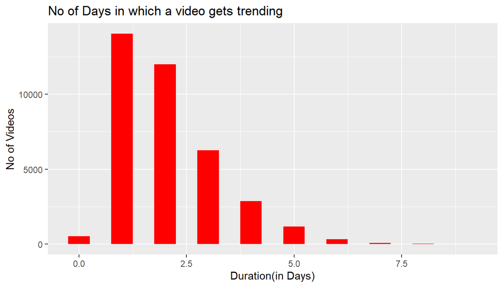

```r
df=df[1:10,]
ggplot(data=df,aes(x=dur_to_trend,y=no_of_videos))+geom_bar(stat = "identity",width=0.5,fill="red")+labs(title = "No of Days in which a video gets trending", y="No of Videos", x= "Duration(in Days)")
```

### Analysis of Views on trending videos

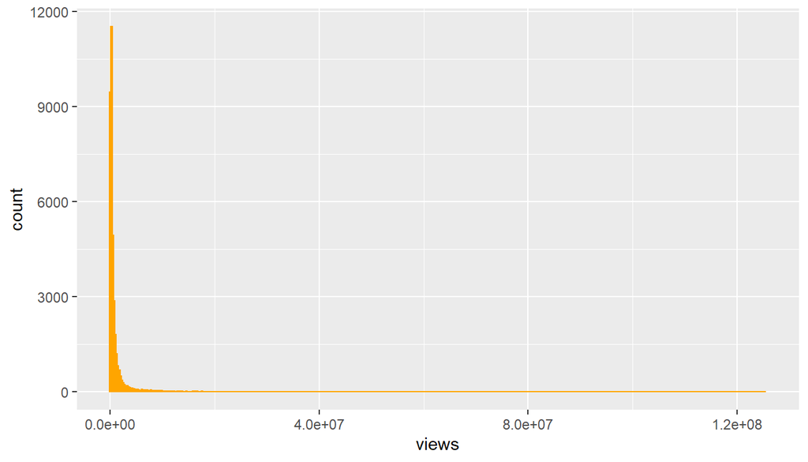

```r
ggplot(data =ind_data, aes(views))+geom_histogram(color="orange",fill="orange", bins = 500 )
```

### Analysis of Likes

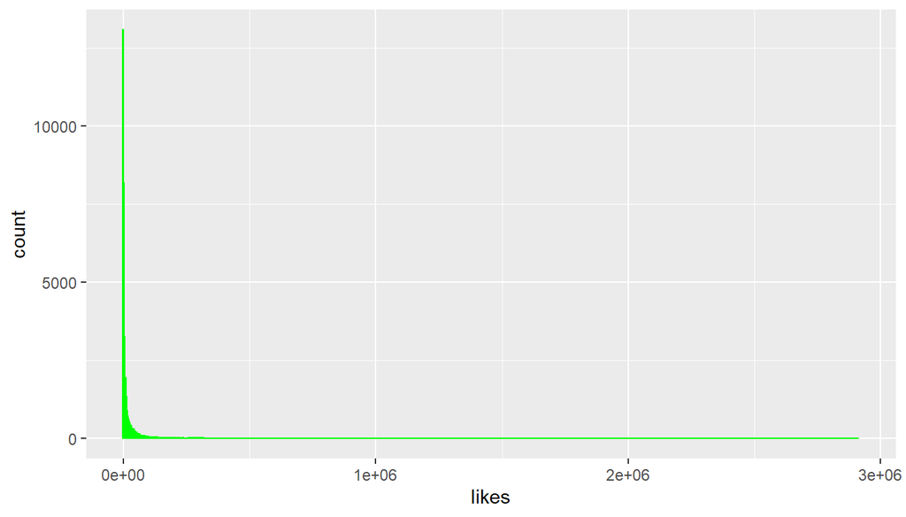

```r
ggplot(data =ind_data, aes(likes))+geom_histogram(color="green",fill="green",bins=1000)
```

### Analysis of Category

```r
df=ind_data%>%
  group_by(temp)%>%
  summarise(no_of_videos=n())
```

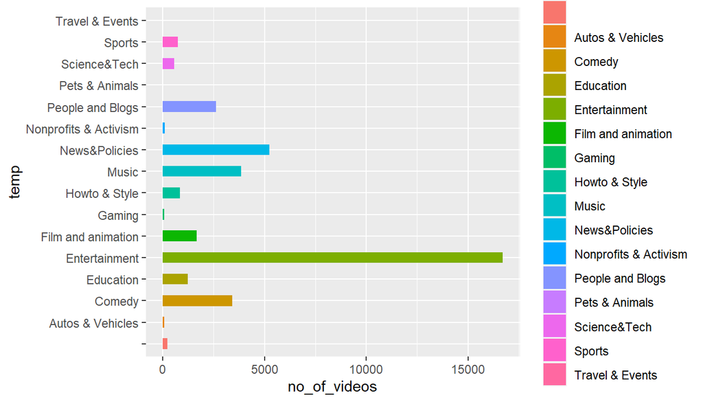

```r
ggplot(data=df,aes(x=temp,y=no_of_videos,fill=temp))+geom_bar(stat = "identity",width = 0.5)+coord_flip()
```

```r
idx=which.min(df$no_of_videos)
df[idx,]
```

```
## # A tibble: 1 x 2
##   temp           no_of_videos
##   <chr>                 <int>
## 1 Pets & Animals            3
```

#### In India people are fond of watching Videos belonging to Entertainment genre. They also like to watch blogs, news and comedy.

#### And they videos belonging to pets and animals, gaming and travel seems to have less creativity.

### Analysis of Channels

```r
df=ind_data%>%
  group_by(channel_title)%>%
  summarise(no_of_videos=n())
df$no_of_videos=sort(df$no_of_videos,decreasing = TRUE)
df[1:20,]
```

```
## # A tibble: 20 x 2
##    channel_title            no_of_videos
##    <chr>                           <int>
##  1 #Mind Warehouse                   284
##  2 1 Kg Biriyani                     282
##  3 1 Minutes news                    270
##  4 10 DEGREE INDIAN FACTS            253
##  5 10TVNewsChannel                   244
##  6 2 Minute News Today               243
##  7 2 Minutes News                    238
##  8 20th Century Fox                  238
##  9 24 ghanta                         234
## 10 24 Tamil Health & Beauty          231
## 11 2Day 2Morrow                      223
## 12 2DayCinema                        221
## 13 3TV BANJARAA                      220
## 14 4G Entertainments                 215
## 15 5-Minute Crafts                   213
## 16 5AABTODAY CHANNEL                 212
## 17 5nMedia                           198
## 18 5ocial                            197
## 19 6TV Telangana                     196
## 20 7070 sports                       193
```

```r
df=ind_data%>%
  group_by(channel_title,temp)%>%
  summarise(no_of_videos=n())
df$no_of_videos=sort(df$no_of_videos,decreasing = TRUE)
df[1:20,]
```

```
## # A tibble: 20 x 3
## # Groups:   channel_title [4]
##    channel_title          temp               no_of_videos
##    <chr>                  <chr>                     <int>
##  1 #Mind Warehouse        Comedy                      131
##  2 #Mind Warehouse        Entertainment               123
##  3 1 Kg Biriyani          Comedy                      123
##  4 1 Kg Biriyani          Education                   119
##  5 1 Kg Biriyani          Entertainment               115
##  6 1 Kg Biriyani          Film and animation          109
##  7 1 Kg Biriyani          Howto & Style               109
##  8 1 Kg Biriyani          Music                       108
##  9 1 Kg Biriyani          News&Policies               108
## 10 1 Kg Biriyani          People and Blogs            106
## 11 1 Kg Biriyani          Sports                      105
## 12 1 Minutes news         Education                   105
## 13 1 Minutes news         Entertainment               104
## 14 1 Minutes news         Film and animation           99
## 15 1 Minutes news         Music                        91
## 16 1 Minutes news         News&Policies                89
## 17 1 Minutes news         People and Blogs             85
## 18 1 Minutes news         Science&Tech                 83
## 19 10 DEGREE INDIAN FACTS Comedy                       82
## 20 10 DEGREE INDIAN FACTS Education                    81
```

```r
df=df[1:100,]
df=df%>%
  group_by(temp)%>%
  summarise(total_video=sum(no_of_videos))
df
```

```
## # A tibble: 11 x 2
##    temp                 total_video
##    <chr>                      <int>
##  1 ""                            47
##  2 "Comedy"                     888
##  3 "Education"                  500
##  4 "Entertainment"             1056
##  5 "Film and animation"         644
##  6 "Howto & Style"              518
##  7 "Music"                      650
##  8 "News&Policies"              728
##  9 "People and Blogs"           751
## 10 "Science&Tech"               242
## 11 "Sports"                     496
```

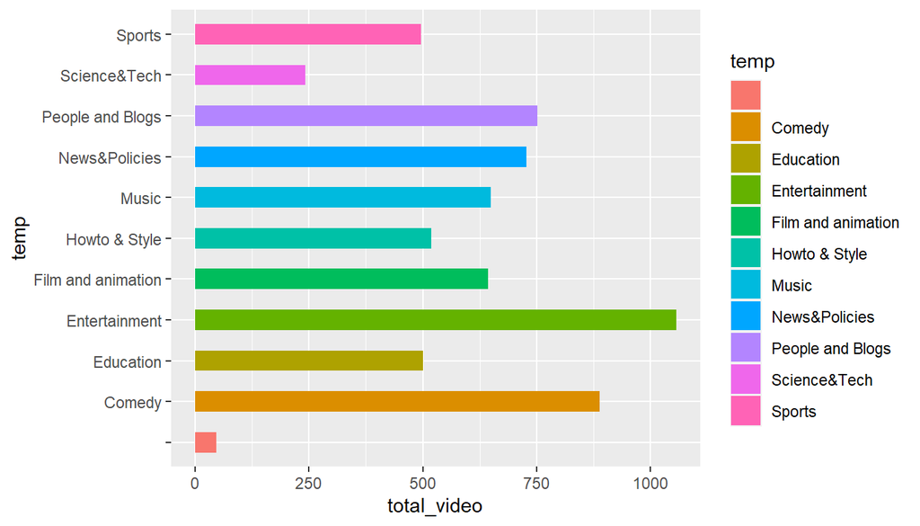

```r
ggplot(data=df,aes(x=temp,y=total_video,fill=temp))+geom_bar(stat = "identity",width = 0.5)+coord_flip()
```

### Analysis on Day of Publication

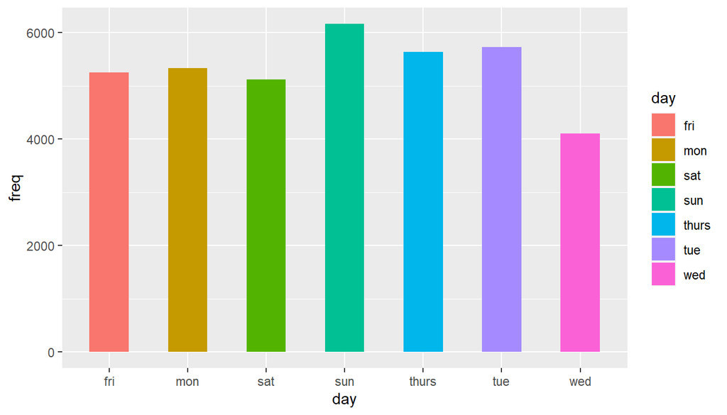

```r
freq=table(ind_data$day_pub)
day=c("sun","mon","tue","wed","thurs","fri","sat")
df=data.frame(day,freq)
ggplot(data=df,aes(x=day,y=freq,fill=day))+geom_bar(stat = "identity",width = 0.5)
```

### Analysis on Time of Publication

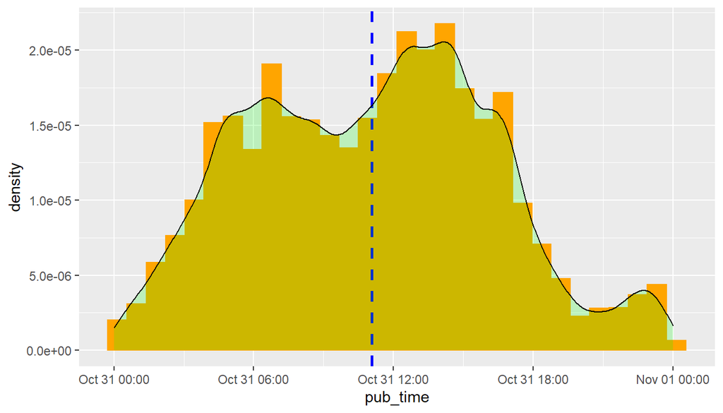

```r
ind_data$pub_time=as.POSIXct(ind_data$pub_time,format="%H:%M:%S")
ggplot(data =ind_data, aes(pub_time))+geom_histogram(aes(y=..density..),color="orange",fill="orange")+geom_vline(aes(xintercept=mean(pub_time)),color="blue",linetype="dashed",size=1)+geom_density(alpha=.2,fill="green")
```

#### The best time to upload the videos is between 12 noon to 6 in the evening.

## Comaprison with other regions

### Reading data of diff regions

```r
gb_data=read.csv("GBvideos.csv")
us_data=read.csv("USvideos.csv")
jp_data=read.csv("JPvideos.csv")
```

### Data Preprocessing and Data Cleaning for GB Dataset

```r
pub_time=substr(gb_data$publish_time,12,19)
gb_data=cbind(gb_data,pub_time)

temp=rep("20",times=nrow(gb_data))
gb_data$trending_date=paste(temp,gb_data$trending_date,sep = "")
gb_data$trending_date=gsub("[.]","-",gb_data$trending_date)
gb_data$trending_date=as.POSIXct(gb_data$trending_date,format="%Y-%d-%m")

day_pub=wday(gb_data$publish_time,label = TRUE)
gb_data=cbind(gb_data,day_pub)
gb_data$day_pub=as.character(gb_data$day_pub)

dur_to_trend=difftime(gb_data$trending_date,gb_data$publish_time,units = "days")
gb_data=cbind(gb_data,dur_to_trend)

temp=unique(gb_data$category_id)
idx=1
temp=rep("",times=nrow(gb_data))
for(i in gb_data$category_id){
  if(i==1){
    temp[idx]="Film and animation"
    idx=idx+1
  }
  else if(i==2){
    temp[idx]="Autos & Vehicles"
    idx=idx+1
  }
  else if(i==10){
    temp[idx]="Music"
    idx=idx+1
  }
  else if(i==15){
    temp[idx]="Pets & Animals"
    idx=idx+1
  }
  else if(i==17){
    temp[idx]="Sports"
    idx=idx+1
  }
  else if(i==19){
    temp[idx]="Travel & Events"
    idx=idx+1
  }
  else if(i==20){
    temp[idx]="Gaming"
    idx=idx+1
  }
  else if(i==22){
    temp[idx]="People and Blogs"
    idx=idx+1
  }
  else if(i==23){
    temp[idx]="Comedy"
    idx=idx+1
  }
  else if(i==24){
    temp[idx]="Entertainment"
    idx=idx+1
  }
  else if(i==25){
    temp[idx]="News&Policies"
    idx=idx+1
  }
  else if(i==26){
    temp[idx]="Howto & Style"
    idx=idx+1
  }
  else if(i==27){
    temp[idx]="Education"
    idx=idx+1
  }
  else if(i==28){
    temp[idx]="Science&Tech"
    idx=idx+1
  }
  else if(i==29){
    temp[idx]="Nonprofits & Activism"
    idx=idx+1
  }
}
gb_data=cbind(gb_data,temp)
```

### Data Preprocessing and Data Cleaning for US Dataset

```r
pub_time=substr(us_data$publish_time,12,19)
us_data=cbind(us_data,pub_time)

temp=rep("20",times=nrow(us_data))
us_data$trending_date=paste(temp,us_data$trending_date,sep = "")
us_data$trending_date=gsub("[.]","-",us_data$trending_date)
us_data$trending_date=as.POSIXct(us_data$trending_date,format="%Y-%d-%m")

day_pub=wday(us_data$publish_time,label = TRUE)
us_data=cbind(us_data,day_pub)
us_data$day_pub=as.character(us_data$day_pub)

dur_to_trend=difftime(us_data$trending_date,us_data$publish_time,units = "days")
us_data=cbind(us_data,dur_to_trend)

temp=unique(us_data$category_id)
idx=1
temp=rep("",times=nrow(us_data))
for(i in us_data$category_id){
  if(i==1){
    temp[idx]="Film and animation"
    idx=idx+1
  }
  else if(i==2){
    temp[idx]="Autos & Vehicles"
    idx=idx+1
  }
  else if(i==10){
    temp[idx]="Music"
    idx=idx+1
  }
  else if(i==15){
    temp[idx]="Pets & Animals"
    idx=idx+1
  }
  else if(i==17){
    temp[idx]="Sports"
    idx=idx+1
  }
  else if(i==19){
    temp[idx]="Travel & Events"
    idx=idx+1
  }
  else if(i==20){
    temp[idx]="Gaming"
    idx=idx+1
  }
  else if(i==22){
    temp[idx]="People and Blogs"
    idx=idx+1
  }
  else if(i==23){
    temp[idx]="Comedy"
    idx=idx+1
  }
  else if(i==24){
    temp[idx]="Entertainment"
    idx=idx+1
  }
  else if(i==25){
    temp[idx]="News&Policies"
    idx=idx+1
  }
  else if(i==26){
    temp[idx]="Howto & Style"
    idx=idx+1
  }
  else if(i==27){
    temp[idx]="Education"
    idx=idx+1
  }
  else if(i==28){
    temp[idx]="Science&Tech"
    idx=idx+1
  }
  else if(i==29){
    temp[idx]="Nonprofits & Activism"
    idx=idx+1
  }
}
us_data=cbind(us_data,temp)
```

### Data Preprocessing and Data Cleaning for JP Dataset

```r
pub_time=substr(jp_data$publish_time,12,19)
jp_data=cbind(jp_data,pub_time)

temp=rep("20",times=nrow(jp_data))
jp_data$trending_date=paste(temp,jp_data$trending_date,sep = "")
jp_data$trending_date=gsub("[.]","-",jp_data$trending_date)
jp_data$trending_date=as.POSIXct(jp_data$trending_date,format="%Y-%d-%m")

day_pub=wday(jp_data$publish_time,label = TRUE)
jp_data=cbind(jp_data,day_pub)
jp_data$day_pub=as.character(jp_data$day_pub)

dur_to_trend=difftime(jp_data$trending_date,jp_data$publish_time,units = "days")
jp_data=cbind(jp_data,dur_to_trend)

temp=unique(jp_data$category_id)
idx=1
temp=rep("",times=nrow(jp_data))
for(i in jp_data$category_id){
  if(i==1){
    temp[idx]="Film and animation"
    idx=idx+1
  }
  else if(i==2){
    temp[idx]="Autos & Vehicles"
    idx=idx+1
  }
  else if(i==10){
    temp[idx]="Music"
    idx=idx+1
  }
  else if(i==15){
    temp[idx]="Pets & Animals"
    idx=idx+1
  }
  else if(i==17){
    temp[idx]="Sports"
    idx=idx+1
  }
  else if(i==19){
    temp[idx]="Travel & Events"
    idx=idx+1
  }
  else if(i==20){
    temp[idx]="Gaming"
    idx=idx+1
  }
  else if(i==22){
    temp[idx]="People and Blogs"
    idx=idx+1
  }
  else if(i==23){
    temp[idx]="Comedy"
    idx=idx+1
  }
  else if(i==24){
    temp[idx]="Entertainment"
    idx=idx+1
  }
  else if(i==25){
    temp[idx]="News&Policies"
    idx=idx+1
  }
  else if(i==26){
    temp[idx]="Howto & Style"
    idx=idx+1
  }
  else if(i==27){
    temp[idx]="Education"
    idx=idx+1
  }
  else if(i==28){
    temp[idx]="Science&Tech"
    idx=idx+1
  }
  else if(i==29){
    temp[idx]="Nonprofits & Activism"
    idx=idx+1
  }
}
jp_data=cbind(jp_data,temp)
```

### Total number of videos

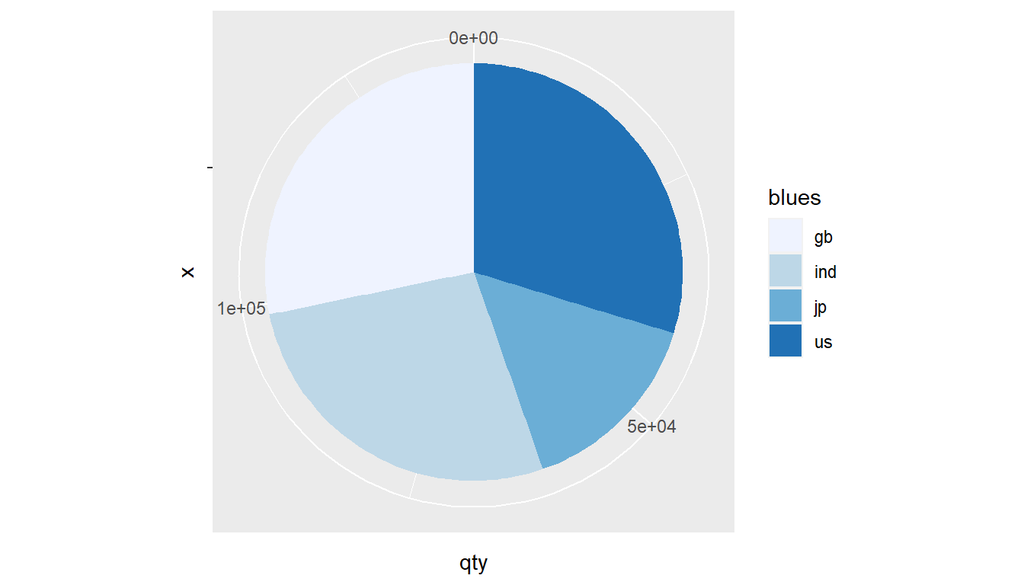

```r
reg=c("ind","gb","us","jp")
qty=c(nrow(ind_data),nrow(gb_data), nrow(us_data),nrow(jp_data))
df=data.frame(reg,qty)

ggplot(df,aes(x="",y=qty,fill=reg))+geom_bar(width=1, stat="identity")+coord_polar("y",start = 0)+scale_fill_brewer("blues")
```

### Comparison on the basis of Views

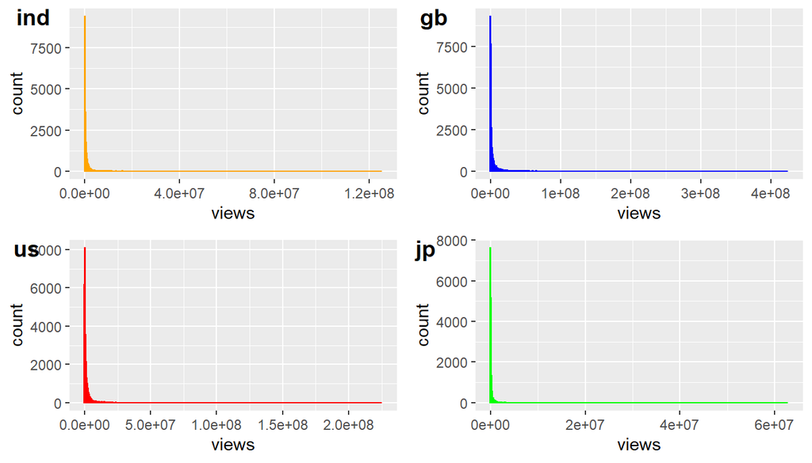

```r
p1=ggplot(data =ind_data, aes(views))+geom_histogram(color="orange",fill="orange", bins = 1000)
p2=ggplot(data =gb_data, aes(views))+geom_histogram(color="blue",fill="blue", bins = 900)
p3=ggplot(data =us_data, aes(views))+geom_histogram(color="red",fill="red", bins = 900)
p4=ggplot(data =jp_data, aes(views))+geom_histogram(color="green",fill="green", bins = 900)
ggarrange(p1,p2,p3,p4,labels=c("ind","gb","us","jp"), ncol=2,nrow=2)
```

### Analysis of Period between video uploaded and getting on trending section

```r
df=ind_data%>%
  group_by(dur_to_trend)%>%
  summarise(no_of_videos=n())
```

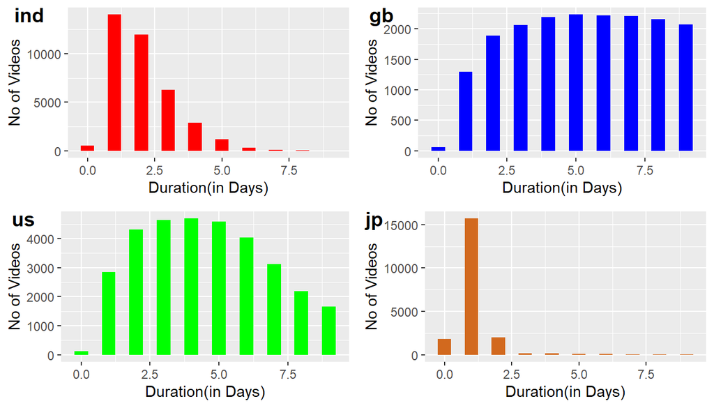

```r
df=df[1:10,]
p1=ggplot(data=df,aes(x=dur_to_trend,y=no_of_videos))+geom_bar(stat = "identity",width=0.5,fill="red")+labs(y="No of Videos", x= "Duration(in Days)")

df=gb_data%>%
  group_by(dur_to_trend)%>%
  summarise(no_of_videos=n())
df=df[1:10,]
p2=ggplot(data=df,aes(x=dur_to_trend,y=no_of_videos))+geom_bar(stat = "identity",width=0.5,fill="blue")+labs(y="No of Videos", x= "Duration(in Days)")

df=us_data%>%
  group_by(dur_to_trend)%>%
  summarise(no_of_videos=n())
df=df[1:10,]
p3=ggplot(data=df,aes(x=dur_to_trend,y=no_of_videos))+geom_bar(stat = "identity",width=0.5,fill="green")+labs(y="No of Videos", x= "Duration(in Days)")

df=jp_data%>%
  group_by(dur_to_trend)%>%
  summarise(no_of_videos=n())
df=df[1:10,]
p4=ggplot(data=df,aes(x=dur_to_trend,y=no_of_videos))+geom_bar(stat = "identity",width=0.5,fill="chocolate")+labs(y="No of Videos", x= "Duration(in Days)")

ggarrange(p1,p2,p3,p4,labels=c("ind","gb","us","jp"), ncol=2,nrow=2)
```

#### So, it can be seen that in India and Japan it takes less than 2 days to get the videos in the trending list, where as in US and UK videos may take more than a week to be on the trending list.

### Category Trending Comaprison

```r
df=ind_data%>%
  group_by(temp)%>%
  summarise(no_of_videos=n())
```

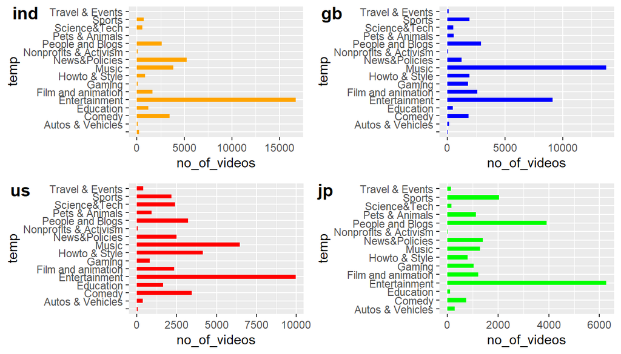

```r
p1=ggplot(data=df,aes(x=temp,y=no_of_videos))+geom_bar(stat = "identity",width = 0.5, fill="orange")+coord_flip()

df=gb_data%>%
  group_by(temp)%>%
  summarise(no_of_videos=n())
p2=ggplot(data=df,aes(x=temp,y=no_of_videos))+geom_bar(stat = "identity",width = 0.5,fill="blue")+coord_flip()


df=us_data%>%
  group_by(temp)%>%
  summarise(no_of_videos=n())
p3=ggplot(data=df,aes(x=temp,y=no_of_videos))+geom_bar(stat = "identity",width = 0.5, fill="red")+coord_flip()


df=jp_data%>%
  group_by(temp)%>%
  summarise(no_of_videos=n())
p4=ggplot(data=df,aes(x=temp,y=no_of_videos))+geom_bar(stat = "identity",width = 0.5,fill="green")+coord_flip()

ggarrange(p1,p2,p3,p4,labels=c("ind","gb","us","jp"), ncol=2,nrow=2)
```

#### All regions except UK we can see that entertainment genre has got on the trending list most number of times but in UK, videos belonging to Music genre got the most number of videos in the trending list.

### Comaprison on day of publication

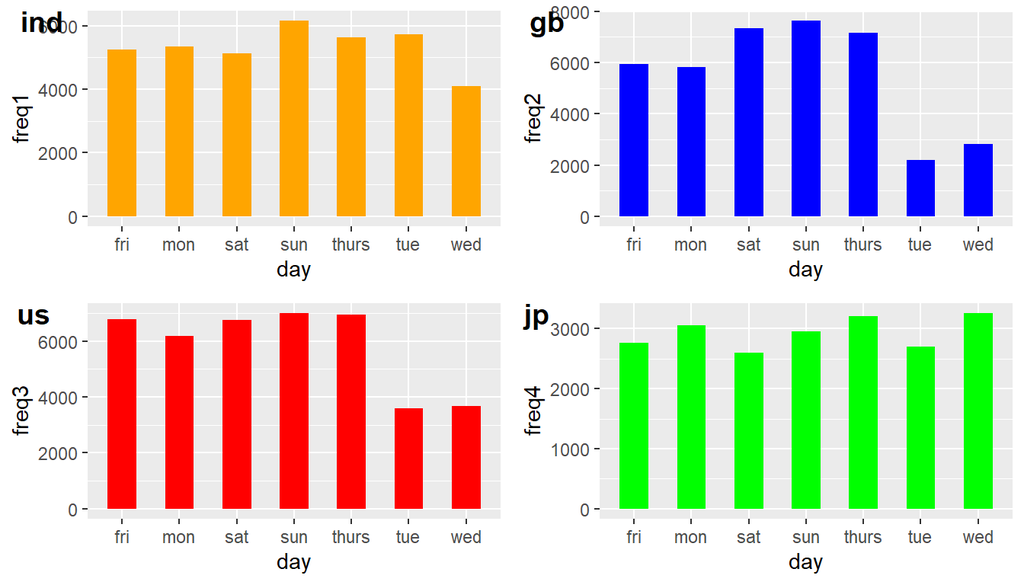

```r
freq1=table(ind_data$day_pub)
day=c("sun","mon","tue","wed","thurs","fri","sat")
df1=data.frame(day,freq1)
p1=ggplot(data=df1,aes(x=day,y=freq1))+geom_bar(stat = "identity",width = 0.5,fill="orange")

freq2=table(gb_data$day_pub)
df2=data.frame(day,freq2)
p2=ggplot(data=df2,aes(x=day,y=freq2))+geom_bar(stat = "identity",width = 0.5,fill="blue")

freq3=table(us_data$day_pub)
df3=data.frame(day,freq3)
p3=ggplot(data=df3,aes(x=day,y=freq3))+geom_bar(stat = "identity",width = 0.5,fill="red")

freq4=table(jp_data$day_pub)
df4=data.frame(day,freq4)
p4=ggplot(data=df4,aes(x=day,y=freq4))+geom_bar(stat = "identity",width = 0.5,fill="green")
ggarrange(p1,p2,p3,p4,labels=c("ind","gb","us","jp"), ncol=2,nrow=2)
```

### Comaprison of Time of publish

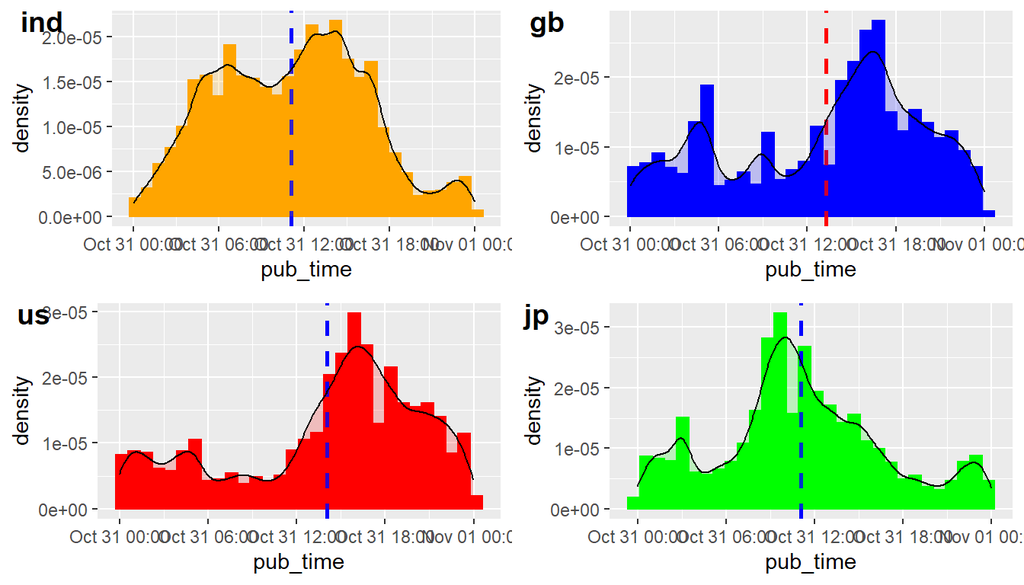

```r
ind_data$pub_time=as.POSIXct(ind_data$pub_time,format="%H:%M:%S")
p1=ggplot(data =ind_data, aes(pub_time))+geom_histogram(aes(y=..density..),color="orange",fill="orange")+geom_vline(aes(xintercept=mean(pub_time)),color="blue",linetype="dashed",size=1)+geom_density(alpha=.2,fill="orange")

gb_data$pub_time=as.POSIXct(gb_data$pub_time,format="%H:%M:%S")
p2=ggplot(data =gb_data, aes(pub_time))+geom_histogram(aes(y=..density..),color="blue",fill="blue")+geom_vline(aes(xintercept=mean(pub_time)),color="red",linetype="dashed",size=1)+geom_density(alpha=.2,fill="blue")

us_data$pub_time=as.POSIXct(us_data$pub_time,format="%H:%M:%S")
p3=ggplot(data =us_data, aes(pub_time))+geom_histogram(aes(y=..density..),color="red",fill="red")+geom_vline(aes(xintercept=mean(pub_time)),color="blue",linetype="dashed",size=1)+geom_density(alpha=.2,fill="red")

jp_data$pub_time=as.POSIXct(jp_data$pub_time,format="%H:%M:%S")
p4=ggplot(data =jp_data, aes(pub_time))+geom_histogram(aes(y=..density..),color="green",fill="green")+geom_vline(aes(xintercept=mean(pub_time)),color="blue",linetype="dashed",size=1)+geom_density(alpha=.2,fill="green")

ggarrange(p1,p2,p3,p4,labels=c("ind","gb","us","jp"), ncol=2,nrow=2)
```

### Correlation Matrix

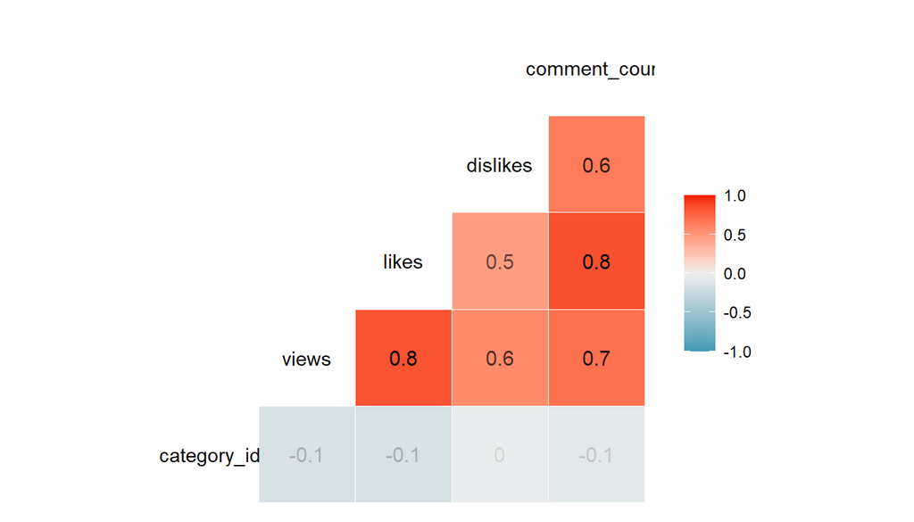

```r
ggcorr(data,label=TRUE,label_alpha = TRUE)
```

### Plotting the graphs between variables to get a visualization of correlation

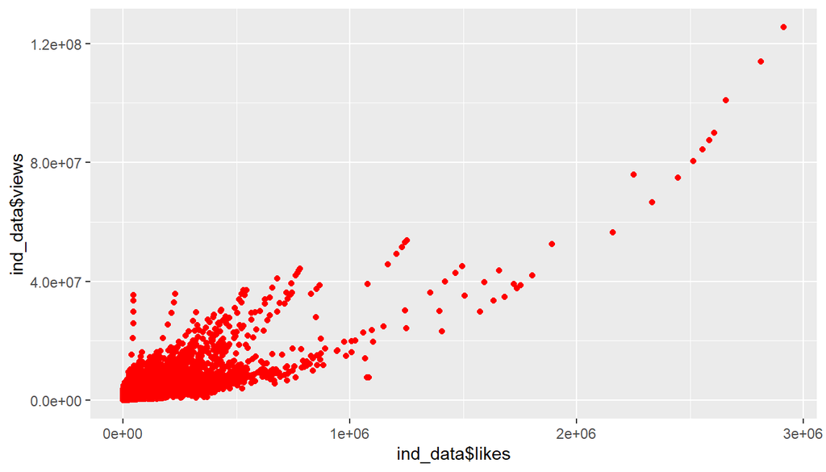

```r
ggplot()+geom_point(aes(x = ind_data$likes, y = ind_data$views),colour = 'red')
```

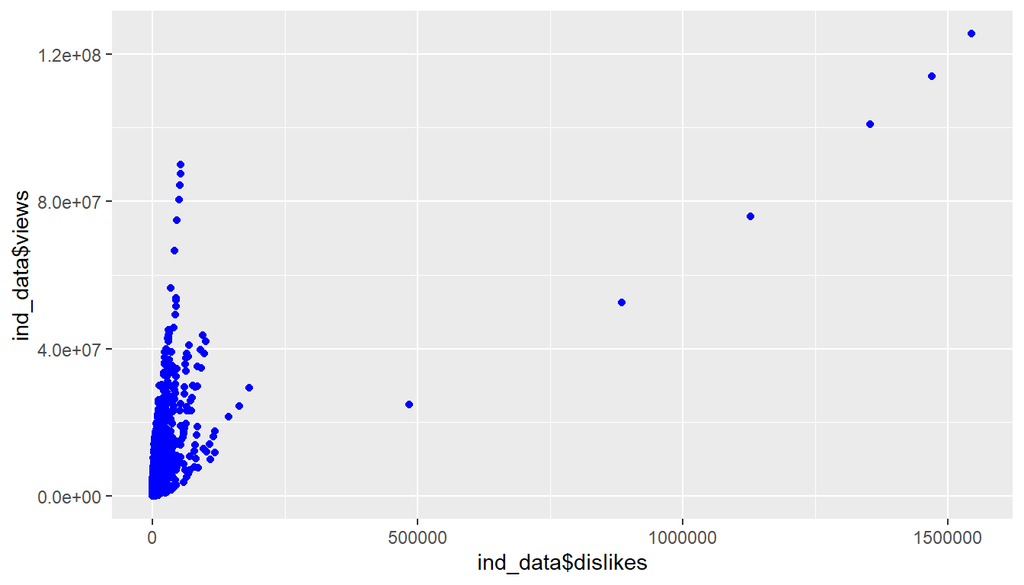

```r
ggplot()+geom_point(aes(x = ind_data$dislikes, y = ind_data$views),colour = 'blue')
```

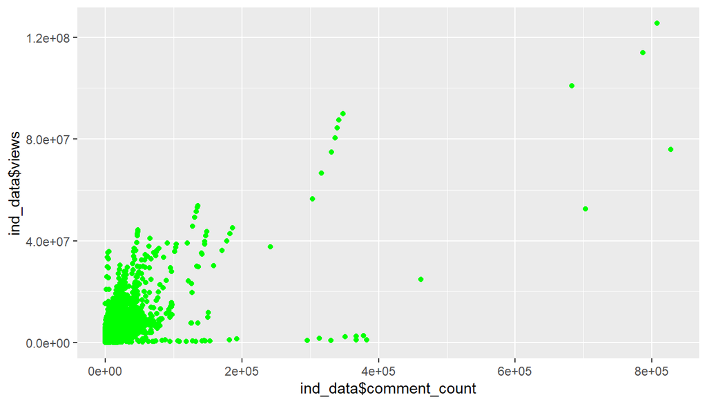

```r
ggplot()+geom_point(aes(x = ind_data$comment_count, y = ind_data$views),colour = 'green')
```

## Predicting Views

### Using Multiple Linear Regression

```r
dataset=ind_data[,c(8,9)]

regressor = lm(formula = views ~ likes, data = dataset)

y_pred = predict(regressor, data.frame(likes = 10000))
y_pred
```

```
##        1
## 584371.1
```

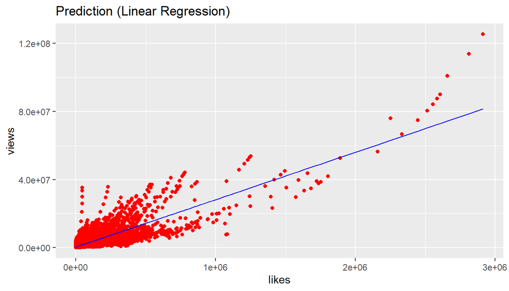

```r
ggplot() + geom_point(aes(x = dataset$likes, y = dataset$views),colour = 'red') + geom_line(aes(x=dataset$likes, y = predict(regressor, newdata = dataset)),colour = 'blue') + ggtitle('Prediction (Linear Regression)') + xlab('likes') + ylab('views')
```

### Using Support Vector Regression

```r
dataset = ind_data

regressor = svm(formula = views ~ likes,
                data = dataset,
                type = 'eps-regression',
                kernel = 'radial')

y_pred = predict(regressor, data.frame(likes = 10000))
y_pred
```

```
##        1
## 564569.6
```

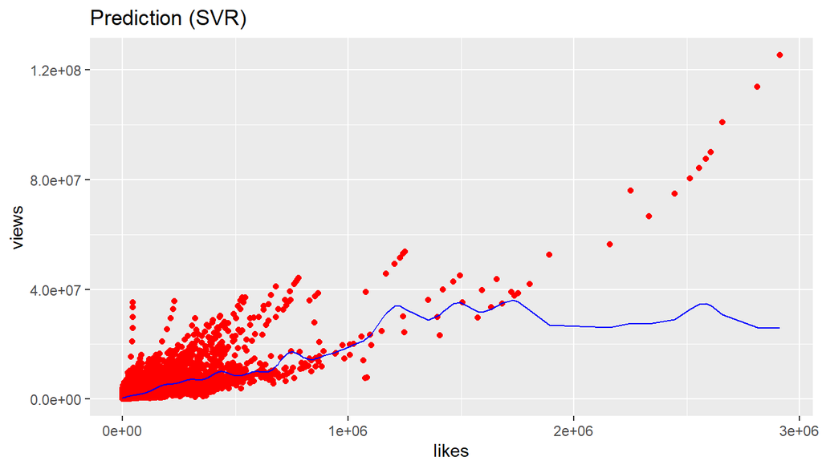

```r
ggplot() +
  geom_point(aes(x = dataset$likes, y = dataset$views),
             colour = 'red') +
  geom_line(aes(x = dataset$likes, y = predict(regressor, newdata = dataset)),
            colour = 'blue') +
  ggtitle('Prediction (SVR)') +
  xlab('likes') +
  ylab('views')
```

### Using Polynomial Regression

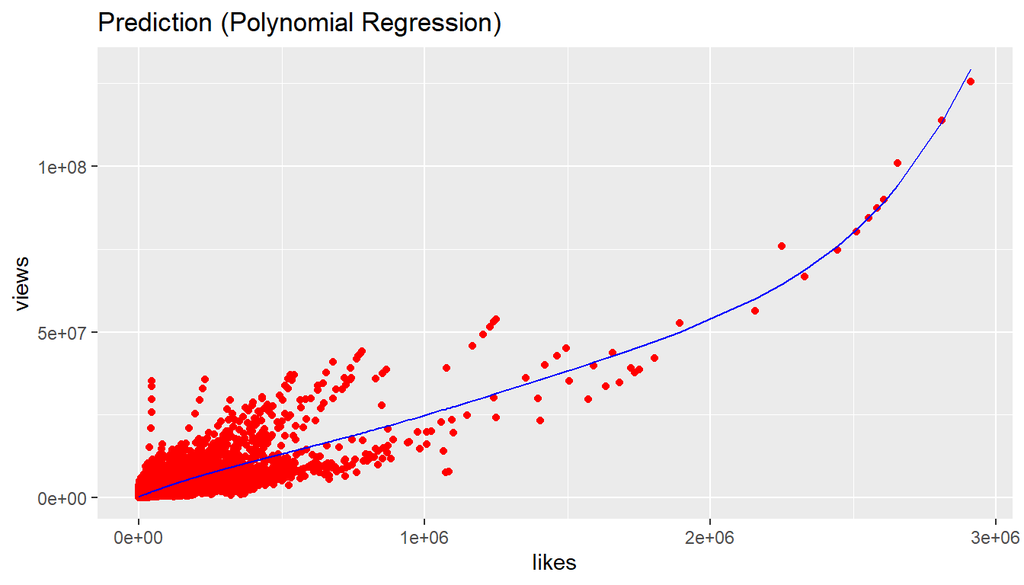

```r
dataset=ind_data[,c(8,9)]

likes2 = dataset$likes^2
likes3 = dataset$likes^3
likes4 = dataset$likes^4
likes5 = dataset$likes^5
likes6 = dataset$likes^6

dataset=cbind(dataset,likes2,likes3,likes4,likes5)

poly_reg = lm(formula = views ~ .,
              data = dataset)

ggplot() + geom_point(aes(x = dataset$likes, y = dataset$views),
             colour = 'red') +
  geom_line(aes(x = dataset$likes, y = predict(poly_reg, newdata = dataset)),
            colour = 'blue') +
  ggtitle('Prediction (Polynomial Regression)') +
  xlab('likes') +
  ylab('views')
```

## Reccomendation of video

#### I have prioritised the reccomendations as channel name > category > tags

### Chennel Name

```r
recm= ind_data%>%
  filter(channel_title=="20th Century Fox")%>%
  select(video_id)
head(recm)
```

```
##      video_id
## 1 8-Cjsnq8kVU
## 2 ykHeGtN4m94
## 3 ykHeGtN4m94
## 4 aj8mN_7Apcw
## 5 aj8mN_7Apcw
## 6 aj8mN_7Apcw
```

### Category

```r
recm= ind_data%>%
  filter(category_id==24)%>%
  select(video_id)

head(recm)
```

```
##      video_id
## 1 10L1hZ9qa58
## 2 kJzGH0PVQHQ
## 3 il_pSa5l98w
## 4 KObFEYCaRx8
## 5 g8QsfJhFpjY
## 6 4du1KXBl4YU
```

### Separating tags

```r
temp=ind_data$tags
tags=strsplit(temp,'"',fixed = TRUE)

head(tags)
```

```
## [[1]]
##  [1] "sharry mann|"                       "sharry mann new song"
##  [3] "|"                                  "sharry mann cute munda"
##  [5] "|"                                  "sharry mann latest song"
##  [7] "|"                                  "sharry mann punjabi song 2017"
##  [9] "|"                                  "parmish verma"
## [11] "|"                                  "parmish verma new song"
## [13] "|"                                  "parmish verma sharry mann"
## [15] "|"                                  "parmish verma sharry mann new song"
## [17] "|"                                  "parmish verma cute munda"
## [19] "|"                                  "new punjabi song 2017"
## [21] "|"                                  "punjabi song 2017"
## [23] "|"                                  "parmish verma new song 2017"
## [25] "|"                                  "parmish verma latest song 2017"
## [27] "|"                                  "punjabi songs 2017"
```

[output cut: 132 more lines]

### Finding Video of corresponding tags

```r
text="MCA"
idx=c()

for (i in c(1 : 10000))
{
    for (j in c(1: length(tags[[i]])))
    {
        if(text==tags[[i]][[j]]){
            idx=append(idx,i)
        }
    }
}

for(i in c(1:length(idx)))
{
  print(ind_data[i,1])
}
```

```
## [1] "kzwfHumJyYc"
## [1] "zUZ1z7FwLc8"
## [1] "10L1hZ9qa58"
## [1] "N1vE8iiEg64"
## [1] "kJzGH0PVQHQ"
## [1] "il_pSa5l98w"
## [1] "7MxiQ4v0EnE"
## [1] "c64I9HNpiOY"
## [1] "KObFEYCaRx8"
## [1] "g8QsfJhFpjY"
## [1] "4du1KXBl4YU"
## [1] "zOOmEDwPJX0"
## [1] "Prb_osSVE0M"
## [1] "KHxdrECEsD0"
## [1] "so0ccfs-psI"
```

[output cut: 23 more lines]

## Comments Prediction:

```r
cmnts=read.csv("UScomments.csv", skipNul = TRUE)

head(cmnts)
```

```
##      video_id
## 1 XpVt6Z1Gjjo
## 2 XpVt6Z1Gjjo
## 3 XpVt6Z1Gjjo
## 4 XpVt6Z1Gjjo
## 5 XpVt6Z1Gjjo
## 6 XpVt6Z1Gjjo
##                                                                              comment_text
## 1                                           Logan Paul it's yo big day â\200¼ï¸\217â\200¼ï¸\217â\200¼ï¸\217
## 2 I've been following you from the start of your vine channel and have seen all 365 vlogs
## 3                                                      Say hi to Kong and maverick for me
## 4                                                                     MY FAN . attendance
## 5                                                                           trending ðŸ\230‰
## 6                                                                 #1 on trending AYYEEEEE
##   likes replies
## 1     4       0
## 2     3       0
## 3     3       0
## 4     3       0
## 5     3       0
## 6     3       0
```

### Predicting whether the cmnt is positive or negative

```r
df=cmnts%>%
  select(comment_text,likes)

for (i in c(1 : 1000))
{
  if(df[i,2]>1){
    df[i,2]=1
  }
}
df=df[1:1000,]
#write.csv(df,"cmnts.csv")
```

#### Reading tsv file

```r
dataset_original = read.delim('cmnts.tsv', quote = '', stringsAsFactors = FALSE)
head(dataset_original)
```

```
##   X
## 1 1
## 2 2
## 3 3
## 4 4
## 5 5
## 6 6
##                                                                              comment_text
## 1                                           Logan Paul it's yo big day â\200¼ï¸\217â\200¼ï¸\217â\200¼ï¸\217
## 2 I've been following you from the start of your vine channel and have seen all 365 vlogs
## 3                                                      Say hi to Kong and maverick for me
## 4                                                                     MY FAN . attendance
## 5                                                                           trending ðŸ\230‰
## 6                                                                 #1 on trending AYYEEEEE
##   likes
## 1     1
## 2     1
## 3     1
## 4     1
## 5     1
## 6     1
```

### Cleaning the text data(tsv file)

```r
library(tm)
library(SnowballC)
corpus = VCorpus(VectorSource(dataset_original$comment_text))
corpus = tm_map(corpus, content_transformer(tolower))
corpus = tm_map(corpus, removeNumbers)
corpus = tm_map(corpus, removePunctuation)
corpus = tm_map(corpus, removeWords, stopwords())
corpus = tm_map(corpus, stemDocument)
corpus = tm_map(corpus, stripWhitespace)
```

### Creating bag of words

```r
dtm = DocumentTermMatrix(corpus)
dtm = removeSparseTerms(dtm, 0.999)
dataset = as.data.frame(as.matrix(dtm))
dataset$likes = dataset_original$likes
dataset$likes = factor(dataset$likes, levels = c(0, 1))

dataset[1:5,20:25]
```

```
##   aib aid aint allow almost alreadi
## 1   0   0    0     0      0       0
## 2   0   0    0     0      0       0
## 3   0   0    0     0      0       0
## 4   0   0    0     0      0       0
## 5   0   0    0     0      0       0
```

### Splitting the dataset into the Training set and Test set

```r
library(caTools)
set.seed(123)

split = sample.split(dataset$likes, SplitRatio = 0.8)
training_set = subset(dataset, split == TRUE)
test_set = subset(dataset, split == FALSE)
```

### Fitting Random Forest Classification to the Training set

```r
library(randomForest)
classifier = randomForest(x = training_set[-692],
                          y = training_set$likes,
                          ntree = 10)

y_pred = predict(classifier, newdata = test_set[-692])

cm = table(test_set[, 692], y_pred)
cm
```

```
##    y_pred
##       0   1
##   0 161  29
##   1   7   1
##   2   2   0
```